# Lecture 6 : Evaluation and interpolation

*May, 2022 - François HU*

*Master of Science - EPITA*

*This lecture is available here: https://curiousml.github.io/*

[figure not shown]

1. Polynomial evaluation
   - Naive method
   - Horner's method
1. Polynomial interpolation
   - Lagrange method
   - (Newton method)
1. Exercices
   - Exercice 1: `eval_polynomial` algorithm
   - Exercice 2: `Horner` algorithm
   - Exercice 3: `lagrange` algorithm

## 1. Polynomial evaluation

Consider a polynomial of degree $k-1$ defined by its $k$ coefficients $a_i$:

$$ P(X) = \sum\limits_{i=0}^{k-1}a_iX^i $$

Our objective is to evaluate this polynomial. We present two ways to do this:

### Naïve approach

**Pseudo-code:**

```
eval_polynomial(a, x)
    Input : list a = (a[0], ..., a[k-1]) and x the point value
    Output : the value of the polynomial P in x: V

    V = a0
    C = x
    for i=1 to k-1 do:
        V = V + ai * C
        C = C * x
```

This algorithm requires $2(k-1)$ multiplications and $k-1$ additions.

### Horner method (first-order)

The idea is to decompose the polynomial so that we have:

$$ P(X) = a_0 + X(a_1 + X(a_2 + X(a_3+\dots+X(a_{k-1})))) $$

**Pseudo-code:**

```
horner(a, x)
    Input : list a = (a[0], ..., a[k-1]) and x the point value
    Output : the value of the polynomial P in x: V

    V = a[k-1]
    for i=k-2 to 0 do:
        V = ai + x * V
```

This algorithm requires $k-1$ multiplications and $k-1$ additions.

### (optional) Horner method (second-order)

The idea is to decompose the polynomial so that we have:

$$ P(X) = \sum\limits_{i=0}^{k-1}a_iX^i = \sum\limits_{i=0}^{k/2-1}a_{2i}X^{2i} + X\cdot\sum\limits_{i=0}^{k/2-1}a_{2i+1}X^{2i+1} = P_0(X^2) + X\cdot P_1(X^2) \implies \text{ Parallelizable approach } $$

## 2. Polynomial interpolation

**Polynomyal interpolation:** given a set of $n + 1$ data points $(x_{0},y_{0}),\ldots ,(x_{n-1},y_{n-1})$, a polynomial function $p ( x ) $ is said to **interpolate** the data if $P(x_{i})=y_{i}$ for each $i\in \{0,1,\dotsc ,n-1\}$

Two common explicit formulas for this polynomial are the **Lagrange polynomials** (and **Newton polynomials**).

### Lagrange polynomials

The polynomial interpolation in the Lagrange form is a linear combination:

$$ Q(X) = \sum\limits_{j=0}^{n-1} y_j P_j(x) $$

with $${\displaystyle Q _{j}(x):=\prod _{\begin{smallmatrix}0\leq m< n\\m\neq j\end{smallmatrix}}{\frac {x-x_{m}}{x_{j}-x_{m}}}={\frac {(x-x_{0})}{(x_{j}-x_{0})}}\cdots {\frac {(x-x_{j-1})}{(x_{j}-x_{j-1})}}{\frac {(x-x_{j+1})}{(x_{j}-x_{j+1})}}\cdots {\frac {(x-x_{n-1})}{(x_{j}-x_{n-1})}},} $$

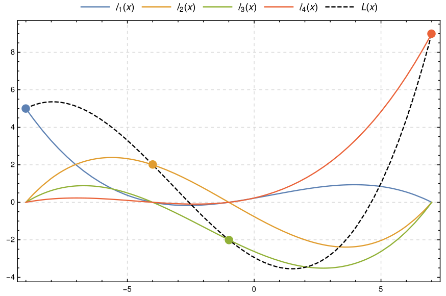

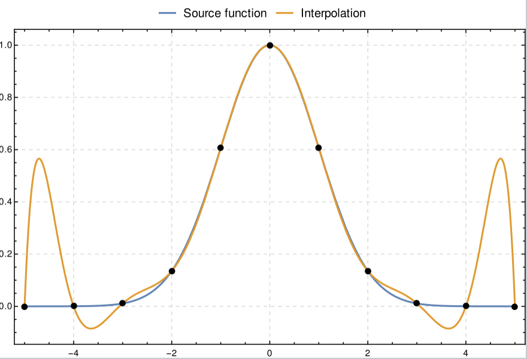

*(source of graphs: wikipedia)*

## 3. Exercices

### Exercice 1: Naïve method

Define a function `eval_polynomial(a, x)` that evaluates the polynomial with coefficient `a` on the point `x` using the Naïve method.

### Exercice 2: Horner method

- Define a function `horner(a, x)` that evaluates the polynomial with coefficient `a` on the point `x` using the first order horner method.
- Compare with the naive method the time complexity

### Exercice 3: Lagrange polynomials

- We have the the following data points $x=[0, 1, 2, 3]$ and $y = [1, 3, -1, 7]$. What is the associated lagrange polynomial ?
- Define a function `lagrange_interpolation(x, y)` that, given the two lists of data points $x = [x_0, \dots, x_{n-1}]$ and $y = [y_0, \dots, y_{n-1}]$, returns the associated Lagrange interpolating polynomial.
- Implement this method on $x=[0, 1, 2, 3]$ and $y = [1, 3, -1, 7]$.
- Illustrate/plot the points with the associated Lagrange polynomial.